# Introduction

## What is the Ranges infrastructure?

The Ranges framework of packages provide data structures and algorithms for analyzing genomic data. This includes standard genomic data containers like `GRanges` and `SummarizedExperiment`, optimized data representations like `Rle`, and fast algorithms for computing overlaps, finding nearest neighbors, summarizing ranges and metadata, and many other useful operations.

## Why use the Ranges infrastructure?

Hundreds of Bioconductor packages operate on Ranges data structures, enabling the construction of complex workflows integrating multiple packages and data types. The API directly supports data analysis as well the construction of new genomic software. Code evolves easily from analysis script to generalized package extending the Bioconductor ecosystem.

## *GRanges*: Genomic Ranges

The central genomic data structure is the `GRanges` class, which represents a collection of genomic ranges that each have a single start and end location on the genome. It can be used to store the location of genomic features such as binding sites, read alignments and transcripts.

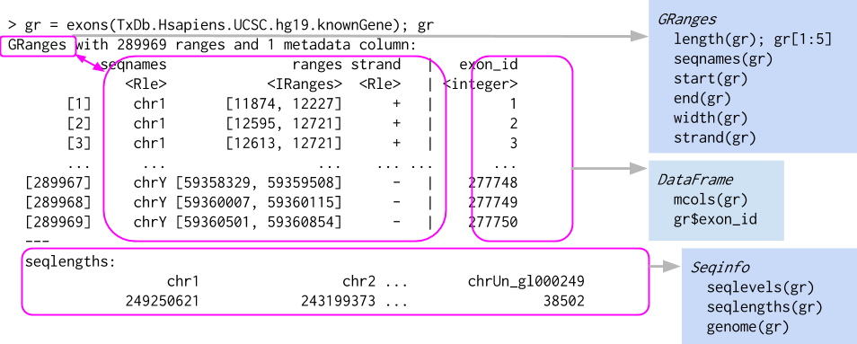

## Constructing a *GRanges* object from data.frame

If we have a `data.frame` containing scores on a set of genomic ranges, we can call `makeGRangesFromDataFrame()` to promote the `data.frame` to a `GRanges`.

This adds semantics, formal constraints, and range-specific functionality.

For example,

```r
suppressPackageStartupMessages({
 library(GenomicRanges)
})
```

```r
df <- data.frame(
    seqnames = rep(c("chr1", "chr2", "chr1", "chr3"), c(1, 3, 2, 4)),
    start = c(101, 105, 125, 132, 134, 152, 153, 160, 166, 170),
    end = c(104, 120, 133, 132, 155, 154, 159, 166, 171, 190),
    strand = rep(strand(c("-", "+", "*", "+", "-")), c(1, 2, 2, 3, 2)),
    score = 1:10,
    GC = seq(1, 0, length=10),
    row.names = head(letters, 10))
gr <- makeGRangesFromDataFrame(df, keep.extra.columns=TRUE)
gr
```

```
## GRanges object with 10 ranges and 2 metadata columns:
##     seqnames    ranges strand |     score                GC
##        <Rle> <IRanges>  <Rle> | <integer>         <numeric>
##   a     chr1   101-104      - |         1                 1
##   b     chr2   105-120      + |         2 0.888888888888889
##   c     chr2   125-133      + |         3 0.777777777777778
##   d     chr2       132      * |         4 0.666666666666667
##   e     chr1   134-155      * |         5 0.555555555555556
##   f     chr1   152-154      + |         6 0.444444444444444
##   g     chr3   153-159      + |         7 0.333333333333333
##   h     chr3   160-166      + |         8 0.222222222222222
##   i     chr3   166-171      - |         9 0.111111111111111
##   j     chr3   170-190      - |        10                 0
##   -------
##   seqinfo: 3 sequences from an unspecified genome; no seqlengths
```

creates a `GRanges` object with 10 genomic ranges. The output of the `show()` method separates the information into a left and right hand region that are separated by `|` symbols.

The genomic coordinates (seqnames, ranges, and strand) are located on the left-hand side and the metadata columns (annotation) are located on the right.

For this example, the metadata is comprised of `"score"` and `"GC"` information, but almost anything can be stored in the metadata portion of a `GRanges` object.

## Loading a *GRanges* object from a standard file format

We often obtain data on genomic ranges from standard track formats, like BED. The rtracklayer package parses those files directly into `GRanges` objects.

The GenomicAlignments package parses BAM files into `GAlignments` objects, which behave much like `GRanges`, and it is easy to convert `GAlignments` to `GRanges`.